# ExtraaLearn Project

## Context

The EdTech industry has been surging in the past decade immensely, and according to a forecast, the Online Education market would be worth $286.62bn by 2023 with a compound annual growth rate (CAGR) of 10.26% from 2018 to 2023. The modern era of online education has enforced a lot in its growth and expansion beyond any limit. Due to having many dominant features like ease of information sharing, personalized learning experience, transparency of assessment, etc, it is now preferable to traditional education.

In the present scenario due to the Covid-19, the online education sector has witnessed rapid growth and is attracting a lot of new customers. Due to this rapid growth, many new companies have emerged in this industry. With the availability and ease of use of digital marketing resources, companies can reach out to a wider audience with their offerings. The customers who show interest in these offerings are termed as leads. There are various sources of obtaining leads for Edtech companies, like

- The customer interacts with the marketing front on social media or other online platforms.
- The customer browses the website/app and downloads the brochure
- The customer connects through emails for more information.

The company then nurtures these leads and tries to convert them to paid customers. For this, the representative from the organization connects with the lead on call or through email to share further details.

## Objective

ExtraaLearn is an initial stage startup that offers programs on cutting-edge technologies to students and professionals to help them upskill/reskill. With a large number of leads being generated on a regular basis, one of the issues faced by ExtraaLearn is to identify which of the leads are more likely to convert so that they can allocate resources accordingly. You, as a data scientist at ExtraaLearn, have been provided the leads data to:

- Analyze and build an ML model to help identify which leads are more likely to convert to paid customers,
- Find the factors driving the lead conversion process
- Create a profile of the leads which are likely to convert

## Data Description

The data contains the different attributes of leads and their interaction details with ExtraaLearn. The detailed data dictionary is given below.

**Data Dictionary**

- ID: ID of the lead
- age: Age of the lead
- current_occupation: Current occupation of the lead. Values include 'Professional','Unemployed',and 'Student'
- first_interaction: How did the lead first interacted with ExtraaLearn. Values include 'Website', 'Mobile App'
- profile_completed: What percentage of profile has been filled by the lead on the website/mobile app. Values include Low - (0-50%), Medium - (50-75%), High (75-100%)
- website_visits: How many times has a lead visited the website
- time_spent_on_website: Total time spent on the website
- page_views_per_visit: Average number of pages on the website viewed during the visits.
- last_activity: Last interaction between the lead and ExtraaLearn.
  - Email Activity: Seeking for details about program through email, Representative shared information with lead like brochure of program , etc
  - Phone Activity: Had a Phone Conversation with representative, Had conversation over SMS with representative, etc
  - Website Activity: Interacted on live chat with representative, Updated profile on website, etc
- print_media_type1: Flag indicating whether the lead had seen the ad of ExtraaLearn in the Newspaper.
- print_media_type2: Flag indicating whether the lead had seen the ad of ExtraaLearn in the Magazine.
- digital_media: Flag indicating whether the lead had seen the ad of ExtraaLearn on the digital platforms.
- educational_channels: Flag indicating whether the lead had heard about ExtraaLearn in the education channels like online forums, discussion threads, educational websites, etc.
- referral: Flag indicating whether the lead had heard about ExtraaLearn through reference.
- status: Flag indicating whether the lead was converted to a paid customer or not.

## Importing necessary libraries and data

```python
# Importing the basic libraries we will require for the project

# Libraries to help with reading and manipulating data
import pandas as pd
import numpy as np

# Libaries to help with data visualization
import matplotlib.pyplot as plt
import seaborn as sns
sns.set()

# Importing the Machine Learning models we require from Scikit-Learn
from sklearn.linear_model import LogisticRegression
from sklearn.svm import SVC
from sklearn.tree import DecisionTreeClassifier
from sklearn import tree
from sklearn.ensemble import RandomForestClassifier

# Importing the other functions we may require from Scikit-Learn
from sklearn.model_selection import train_test_split, GridSearchCV
from sklearn.preprocessing import MinMaxScaler, LabelEncoder, OneHotEncoder
from sklearn.impute import SimpleImputer

# To get diferent metric scores
from sklearn.metrics import confusion_matrix,classification_report,roc_auc_score,precision_recall_curve,roc_curve,make_scorer

# Code to ignore warnings from function usage
import warnings;
import numpy as np
warnings.filterwarnings('ignore')
```

```python
#mount google drive
from google.colab import drive
drive.mount('/content/drive')
```

```python
# Loading the dataset
data=pd.read_csv("/content/drive/MyDrive/MIT Course/Module 4 Classification & Hypothesis Testing/Project/Dataset Potential Customers Prediction.csv")
```

## Data Overview

- Observations
- Sanity checks

```python
#View first 5 rows of data
data.head()
```

|  | ID | age | current_occupation | first_interaction | profile_completed | website_visits | time_spent_on_website | page_views_per_visit | last_activity | print_media_type1 | print_media_type2 | digital_media | educational_channels | referral | status |
| --- | --- | --- | --- | --- | --- | --- | --- | --- | --- | --- | --- | --- | --- | --- | --- |
| 0 | EXT001 | 57 | Unemployed | Website | High | 7 | 1639 | 1.861 | Website Activity | Yes | No | Yes | No | No | 1 |
| 1 | EXT002 | 56 | Professional | Mobile App | Medium | 2 | 83 | 0.320 | Website Activity | No | No | No | Yes | No | 0 |
| 2 | EXT003 | 52 | Professional | Website | Medium | 3 | 330 | 0.074 | Website Activity | No | No | Yes | No | No | 0 |
| 3 | EXT004 | 53 | Unemployed | Website | High | 4 | 464 | 2.057 | Website Activity | No | No | No | No | No | 1 |
| 4 | EXT005 | 23 | Student | Website | High | 4 | 600 | 16.914 | Email Activity | No | No | No | No | No | 0 |

```python
#View last 5 rows of data
data.tail()
```

|  | ID | age | current_occupation | first_interaction | profile_completed | website_visits | time_spent_on_website | page_views_per_visit | last_activity | print_media_type1 | print_media_type2 | digital_media | educational_channels | referral | status |
| --- | --- | --- | --- | --- | --- | --- | --- | --- | --- | --- | --- | --- | --- | --- | --- |
| 4607 | EXT4608 | 35 | Unemployed | Mobile App | Medium | 15 | 360 | 2.170 | Phone Activity | No | No | No | Yes | No | 0 |
| 4608 | EXT4609 | 55 | Professional | Mobile App | Medium | 8 | 2327 | 5.393 | Email Activity | No | No | No | No | No | 0 |
| 4609 | EXT4610 | 58 | Professional | Website | High | 2 | 212 | 2.692 | Email Activity | No | No | No | No | No | 1 |
| 4610 | EXT4611 | 57 | Professional | Mobile App | Medium | 1 | 154 | 3.879 | Website Activity | Yes | No | No | No | No | 0 |
| 4611 | EXT4612 | 55 | Professional | Website | Medium | 4 | 2290 | 2.075 | Phone Activity | No | No | No | No | No | 0 |

```python
#View the shape of the data
data.shape
```

```
(4612, 15)
```

Data has 4612 Rows, 15 Columns

```python
#Check for duplicates
duplicate_rows = data[data.duplicated()]

# Show how many duplicate rows exist
print(f"Number of duplicate rows: {duplicate_rows.shape[0]}")
```

```
Number of duplicate rows: 0
```

Observation: No duplicates found.

```python
#Check data types
data.info()
```

```
<class 'pandas.core.frame.DataFrame'>
RangeIndex: 4612 entries, 0 to 4611
Data columns (total 15 columns):
 #   Column                 Non-Null Count  Dtype
---  ------                 --------------  -----
 0   ID                     4612 non-null   object
 1   age                    4612 non-null   int64
 2   current_occupation     4612 non-null   object
 3   first_interaction      4612 non-null   object
 4   profile_completed      4612 non-null   object
 5   website_visits         4612 non-null   int64
 6   time_spent_on_website  4612 non-null   int64
 7   page_views_per_visit   4612 non-null   float64
 8   last_activity          4612 non-null   object
 9   print_media_type1      4612 non-null   object
 10  print_media_type2      4612 non-null   object
 11  digital_media          4612 non-null   object
 12  educational_channels   4612 non-null   object
 13  referral               4612 non-null   object
 14  status                 4612 non-null   int64
dtypes: float64(1), int64(4), object(10)
memory usage: 540.6+ KB
```

No columns have missing values

- 10 Object Type
- 4 Integer Type
- 1 Float Type

## Exploratory Data Analysis (EDA)

- EDA is an important part of any project involving data.
- It is important to investigate and understand the data better before building a model with it.
- A few questions have been mentioned below which will help you approach the analysis in the right manner and generate insights from the data.
- A thorough analysis of the data, in addition to the questions mentioned below, should be done.

**Questions**

1. Leads will have different expectations from the outcome of the course and the current occupation may play a key role in getting them to participate in the program. Find out how current occupation affects lead status.
2. The company's first impression on the customer must have an impact. Do the first channels of interaction have an impact on the lead status?
3. The company uses multiple modes to interact with prospects. Which way of interaction works best?
4. The company gets leads from various channels such as print media, digital media, referrals, etc. Which of these channels have the highest lead conversion rate?
5. People browsing the website or mobile application are generally required to create a profile by sharing their personal data before they can access additional information.Does having more details about a prospect increase the chances of conversion?

```python
#Check Statistical Summary
data.describe().T
```

|  | count | mean | std | min | 25% | 50% | 75% | max |
| --- | --- | --- | --- | --- | --- | --- | --- | --- |
| age | 4612.0 | 46.201214 | 13.161454 | 18.0 | 36.00000 | 51.000 | 57.00000 | 63.000 |
| website_visits | 4612.0 | 3.566782 | 2.829134 | 0.0 | 2.00000 | 3.000 | 5.00000 | 30.000 |
| time_spent_on_website | 4612.0 | 724.011275 | 743.828683 | 0.0 | 148.75000 | 376.000 | 1336.75000 | 2537.000 |
| page_views_per_visit | 4612.0 | 3.026126 | 1.968125 | 0.0 | 2.07775 | 2.792 | 3.75625 | 18.434 |
| status | 4612.0 | 0.298569 | 0.457680 | 0.0 | 0.00000 | 0.000 | 1.00000 | 1.000 |

**Observations**

**Age**: Most leads are mature adults, likely professionals or adults reskilling/upskilling, rather than traditional college-age students.

**Web Visits**: Most users visit the site 2-5 times, but a few outliers have much higher engagement. Some have 0, suggesting not all leads revisit the website after initial interaction.

**Time Spent on Website**: Very wide variation in time spent, with some leads spending very little time and others spending significant time. The mean is skewed upward by a small number of heavy users.

**Page Views Per Visit**: Mean of 3 pages per visit, but there are some who explore much more.

**Status**: Almost 30% of leads convert to paid customers, which seems relatively high. This could suggest good targeting or that the “lead” definition is already filtered for likely buyers.

**Summary**: Overall there is a high degree of variance for all behavioral metrics, possibly suggesting that segmenting by engagement could be very informative.

```python
#Check count of unique categorical variables

# Making a list of all catrgorical variables
cat_col = list(data.select_dtypes("object").columns)

# Printing number of count of each unique value in each column
for column in cat_col:
    print(data[column].value_counts())
    print('-'*50)
```

```
ID
EXT4612    1
EXT001     1
EXT002     1
EXT003     1
EXT4596    1
          ..
EXT009     1
EXT008     1
EXT007     1
EXT006     1
EXT005     1
Name: count, Length: 4612, dtype: int64
--------------------------------------------------
current_occupation
Professional    2616
Unemployed      1441
Student          555
Name: count, dtype: int64
--------------------------------------------------
first_interaction
Website       2542
Mobile App    2070
Name: count, dtype: int64
--------------------------------------------------
profile_completed
High      2264
Medium    2241
Low        107
Name: count, dtype: int64
--------------------------------------------------
last_activity
Email Activity      2278
Phone Activity      1234
Website Activity    1100
Name: count, dtype: int64
--------------------------------------------------
print_media_type1
No     4115
Yes     497
Name: count, dtype: int64
--------------------------------------------------
print_media_type2
No     4379
Yes     233
Name: count, dtype: int64
--------------------------------------------------
digital_media
No     4085
Yes     527
Name: count, dtype: int64
--------------------------------------------------
educational_channels
No     3907
Yes     705
Name: count, dtype: int64
--------------------------------------------------
referral
No     4519
Yes      93
Name: count, dtype: int64
--------------------------------------------------
```

```python
#Calculate conversion rates for differnt media types & profile compleation
channel_cols = [
    'print_media_type1',
    'print_media_type2',
    'digital_media',
    'educational_channels',
    'referral'
]

print("---- Conversion Rate by Channel ----")
for col in channel_cols:
    summary = (
        data.groupby(col)['status']
        .agg(['count', 'sum'])
        .rename(columns={'count': 'Leads', 'sum': 'Conversions'})
    )
    summary['Conversion Rate (%)'] = (summary['Conversions'] / summary['Leads'] * 100).round(2)
    print(f"\nChannel: {col}")
    print(summary)

print("\n---- Conversion Rate by Profile Completion ----")
profile_summary = (
    data.groupby('profile_completed')['status']
    .agg(['count', 'sum'])
    .rename(columns={'count': 'Leads', 'sum': 'Conversions'})
)
profile_summary['Conversion Rate (%)'] = (profile_summary['Conversions'] / profile_summary['Leads'] * 100).round(2)
print(profile_summary)
```

```
---- Conversion Rate by Channel ----

Channel: print_media_type1
                   Leads  Conversions  Conversion Rate (%)
print_media_type1
No                  4115         1218                29.60
Yes                  497          159                31.99

Channel: print_media_type2
                   Leads  Conversions  Conversion Rate (%)
print_media_type2
No                  4379         1302                29.73
Yes                  233           75                32.19

Channel: digital_media
               Leads  Conversions  Conversion Rate (%)
digital_media
No              4085         1209                29.60
Yes              527          168                31.88

Channel: educational_channels
                      Leads  Conversions  Conversion Rate (%)
educational_channels
No                     3907         1180                30.20
Yes                     705          197                27.94

Channel: referral
          Leads  Conversions  Conversion Rate (%)
referral
No         4519         1314                29.08
Yes          93           63                67.74

---- Conversion Rate by Profile Completion ----
                   Leads  Conversions  Conversion Rate (%)
profile_completed
High                2264          946                41.78
Low                  107            8                 7.48
Medium              2241          423                18.88
```

**Observations**

**Question 1**: Leads most typically are already professionals. This supports previous observations based on age that users tend to be reskilling/upskilling rather than traditional college students.

**Question 2**: There is a decent split for first interaction between mobile app and website, with website coming in a bit ahead.

**Question 4**: Referrals by far have the highest conversion rate—users with a referral are more than 2x more likely to convert. Other media channels do not appear to have much of an effect on conversion rate, with only 1–3% increase or decrease observed.

**Question 5**: Leads with high profile completion are also more than 4x as likely to convert as those with low profile completion, and more than 2x as likely as those with medium profile completion.

```python
#Check for unique values
data.nunique()
```

|  | 0 |
| --- | --- |
| ID | 4612 |
| age | 46 |
| current_occupation | 3 |
| first_interaction | 2 |
| profile_completed | 3 |
| website_visits | 27 |
| time_spent_on_website | 1623 |
| page_views_per_visit | 2414 |
| last_activity | 3 |
| print_media_type1 | 2 |
| print_media_type2 | 2 |
| digital_media | 2 |
| educational_channels | 2 |
| referral | 2 |
| status | 2 |

**dtype:** int64

Obervations: Should drop ID column as it is unique for each lead and will not add value to the model.

Most variables are catagorical except: Time spent on website, pageviews per visit and age.

## Data Preprocessing

- Missing value treatment (if needed)
- Feature engineering (if needed)
- Outlier detection and treatment (if needed)
- Preparing data for modeling
- Any other preprocessing steps (if needed)

```python
# Dropping ID column
data.drop(columns='ID',axis = 1, inplace=True)
```

```python
# Verify ID dropped
print(data.columns)
```

```
Index(['age', 'current_occupation', 'first_interaction', 'profile_completed',
       'website_visits', 'time_spent_on_website', 'page_views_per_visit',
       'last_activity', 'print_media_type1', 'print_media_type2',
       'digital_media', 'educational_channels', 'referral', 'status'],
      dtype='object')
```

```python
# Converting the data type of each categorical variable to 'category'
for column in cat_col:
    if column in data.columns:
        data[column] = data[column].astype('category')
```

## EDA

- It is a good idea to explore the data once again after manipulating it.

```python
# view data types again
data.info()
```

```
<class 'pandas.core.frame.DataFrame'>
RangeIndex: 4612 entries, 0 to 4611
Data columns (total 14 columns):
 #   Column                 Non-Null Count  Dtype
---  ------                 --------------  -----
 0   age                    4612 non-null   int64
 1   current_occupation     4612 non-null   category
 2   first_interaction      4612 non-null   category
 3   profile_completed      4612 non-null   category
 4   website_visits         4612 non-null   int64
 5   time_spent_on_website  4612 non-null   int64
 6   page_views_per_visit   4612 non-null   float64
 7   last_activity          4612 non-null   category
 8   print_media_type1      4612 non-null   category
 9   print_media_type2      4612 non-null   category
 10  digital_media          4612 non-null   category
 11  educational_channels   4612 non-null   category
 12  referral               4612 non-null   category
 13  status                 4612 non-null   int64
dtypes: category(9), float64(1), int64(4)
memory usage: 221.9 KB
```

```python
df = data.copy()
```

# Univariate Analysis

```python
# Defining the hist_box() function
def hist_box(data, col):
    f, (ax_box, ax_hist) = plt.subplots(2, sharex=True, gridspec_kw={'height_ratios': (0.25, 0.75)}, figsize=(12, 7))
    # Adding a graph in each part
    sns.boxplot(data=data, x=col, ax=ax_box, showmeans=True)
    sns.histplot(data=data, x=col, kde=False, ax=ax_hist)
    plt.show()

# Defining bar plot
def bar_plot_cat(data, column):
    percent = (data[column].value_counts(normalize=True) * 100).sort_values(ascending=False)
    plt.figure(figsize=(7, 4))
    percent.plot(kind='bar')
    plt.title(f'Percentage Distribution of {column}')
    plt.ylabel('Percentage (%)')
    plt.xlabel(column)
    plt.xticks(rotation=30)
    plt.tight_layout()
    plt.show()
```

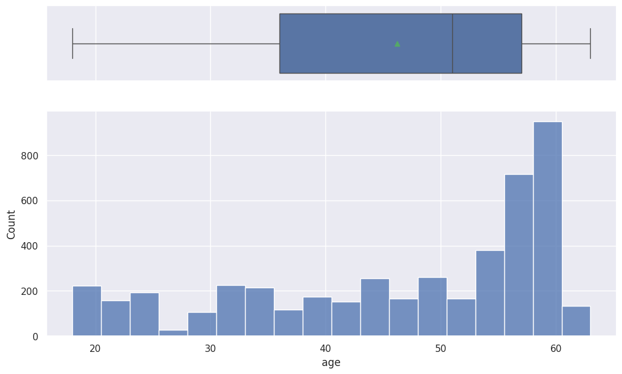

```python
hist_box(df, "age")
```

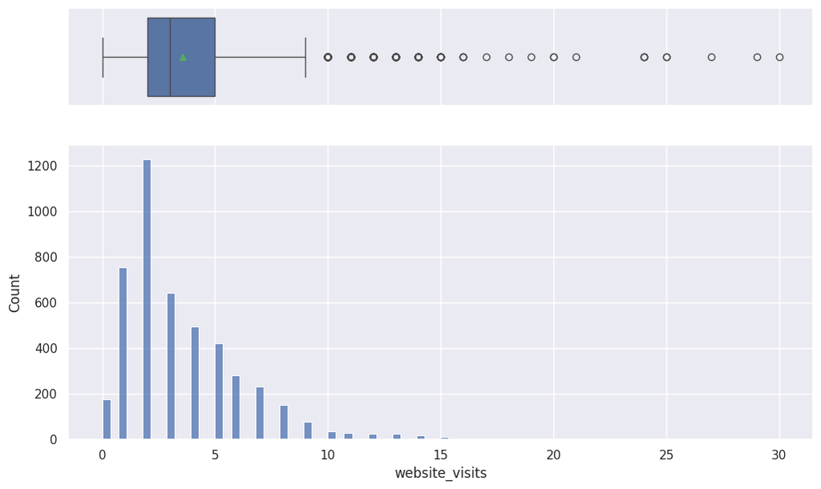

```python
hist_box(df, "website_visits")
```

```python
# To check how many leads have not visited web-site
data[data["website_visits"] == 0].shape
```

```
(174, 14)
```

Website Visit Observations:

The outliers who have visited the site many more times, indicaate some highly engaged leads.

The data is right-skewed where most leads visit a few times, but a small number visit much more often.

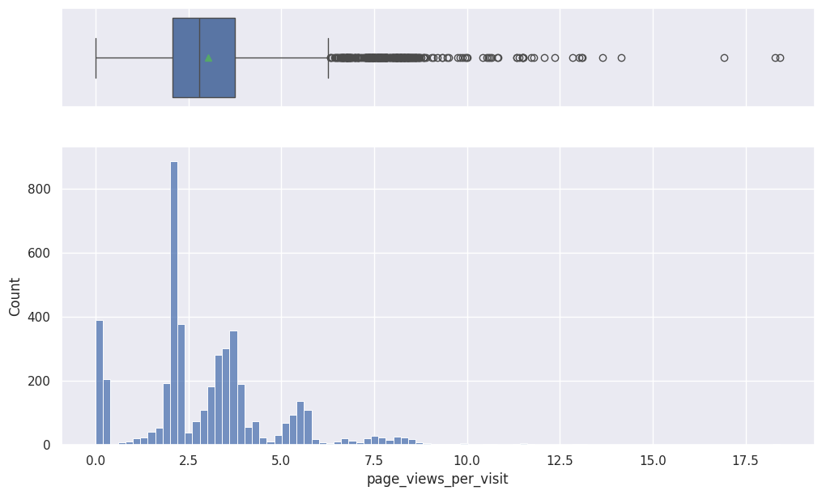

```python
hist_box(df, "page_views_per_visit")
```

Majority of leads have between 2-4 views per visit.

The distribution is also right-skewed with some outliers who view a much higher number of pages per visit.

There are smaller peaks at 0 and 1, indicating some leads have visits with very little engagement.

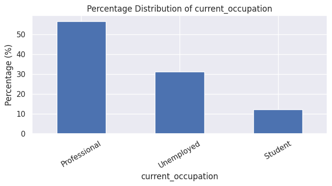

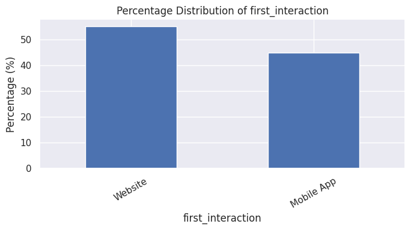

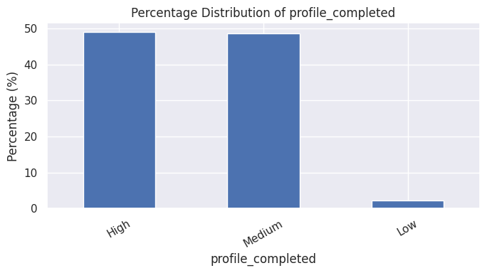

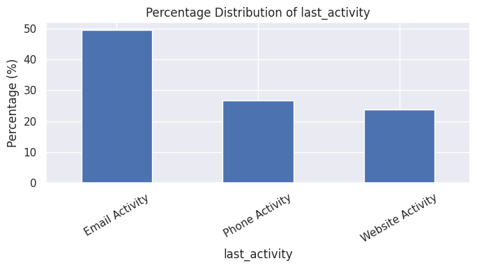

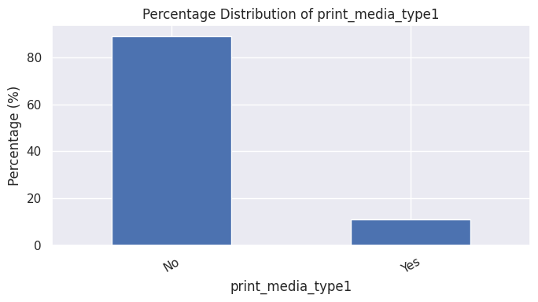

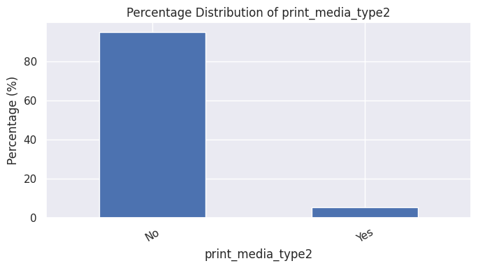

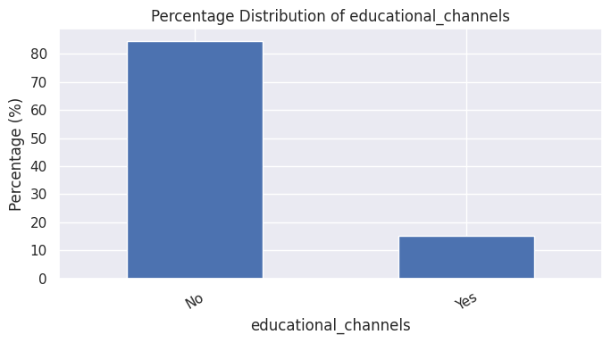

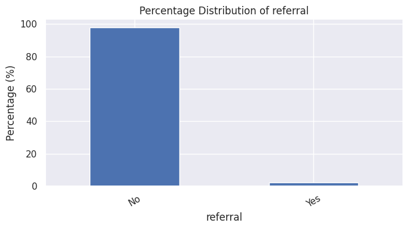

```python
bar_plot_cat(data, "current_occupation")
bar_plot_cat(data, "first_interaction")
bar_plot_cat(data, "profile_completed")
bar_plot_cat(data, "last_activity")
bar_plot_cat(data, "print_media_type1")
bar_plot_cat(data, "print_media_type2")
bar_plot_cat(data, "educational_channels")
bar_plot_cat(data, "referral")
```

Bar Plot Observations:

Reinforcing earlier observations that majority of leads are already part of the workforce.

More leads first interacted via the website, than via the mobile app.

Most leads have medium or high profile completion.

Email Activity is the most common last activity among leads.

Vast majority of leads have not seen the ad in newspapers.

Only about 15% have heard about the company via educational channels.

Univariate Analysis:

Engagement varies widely: While many leads show moderate engagement, there are groups who are either not engaged at all, only view a single page, or are very highly engaged.

Outliers exist in both metrics: A small set of leads is exploring the website much more deeply/frequently, potentially indicating stronger interest or a higher chance of conversion.

Opportunity: Leads with higher website visits and higher page views per visit are likely to be higher quality, more interested, and better candidates for targeted follow-up.

While Refferals drive conversions they are rare, with only about 2 - 3% of leads coming through referral.

Digital-first: Most leads are professionals and first interacted with the company online, not via print or referral.

Print and referral channels contribute a small minority of leads.

Email is the dominant communication channel for last activity, which could influence conversion strategy.

```python
#def stacked bar plot for Bivariate analysis

def stacked_bar(data, x, hue):
    ct = pd.crosstab(data[x], data[hue], normalize='index') * 100
    ct.plot(kind='bar', stacked=True, figsize=(6,4))
    plt.ylabel('Percentage (%)')
    plt.title(f'{hue} distribution by {x}')
    plt.legend(title=hue)
    plt.tight_layout()
    plt.show()
```

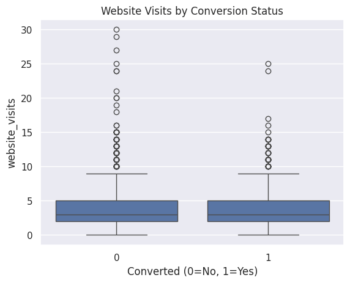

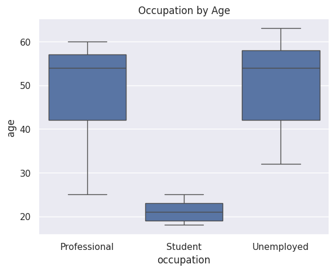

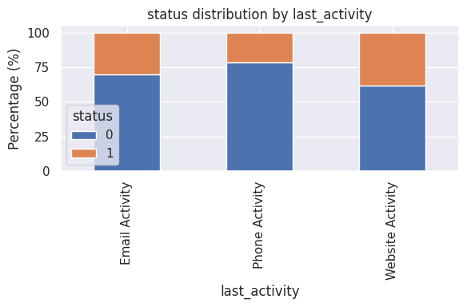

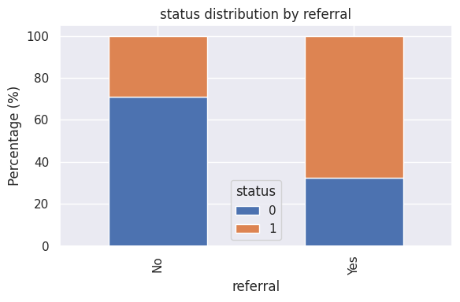

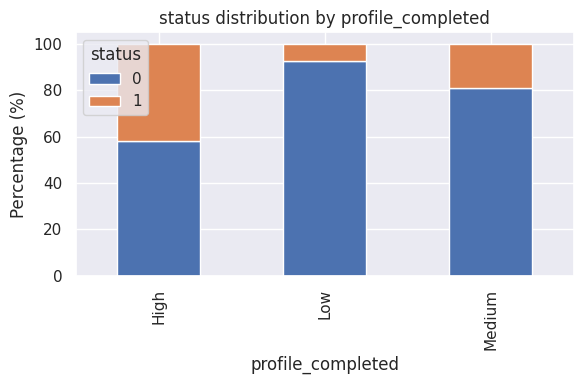

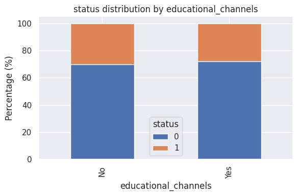

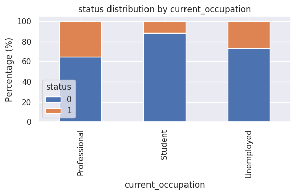

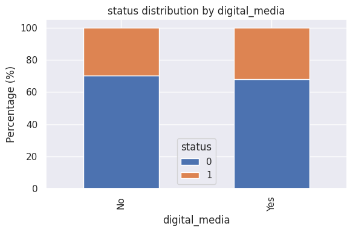

```python
# Boxplot for website visits vs conversion
sns.boxplot(x='status', y='website_visits', data=data)
plt.title('Website Visits by Conversion Status')
plt.xlabel('Converted (0=No, 1=Yes)')
plt.show()

# Boxplot for current occupation & age
sns.boxplot(x='current_occupation', y='age', data=data)
plt.title('Occupation by Age')
plt.xlabel('occupation')
plt.show()

# checking the median value of time on site
data.groupby(["status"])["time_spent_on_website"].median()

#plot latest activity vs status
stacked_bar(data, 'last_activity', 'status')

#plot referral and status
stacked_bar(data, 'referral', 'status')

#plot  profile_completed and status
stacked_bar(data, 'profile_completed', 'status')

#plot educational_channels and status
stacked_bar(data, 'educational_channels', 'status')

#plot current Occupation and status
stacked_bar(data, 'current_occupation', 'status')

#plot digital media and status
stacked_bar(data, 'digital_media', 'status')
```

Bivariate Observations & Analysis

Median website visits are similar for both converted and non-converted leads. Both groups have a similar spread and outliers, suggesting website visits alone may not be a strong differentiator for conversion.

Professionals and Unemployed leads have higher and broader age ranges showing a clear age split by occupation, reflecting typical life stages.

Again Referrals are a highly effective acquisition channel.

Profile completion is a strong predictor of conversion—more completed profiles mean higher intent.

Not much difference between Yes and NO for digital media and educational channels: conversion rates are similar for both.

Targeting professionals/unemployed may yield better conversion than focusing on students.

Referrals and high profile completion are the strongest predictors of conversion.

Student leads are least likely to convert; professionals and unemployed adults are more promising.

Website visit count, digital media, and educational channels alone do not substantially predict conversion.

```python
#Check for outliers
def find_outliers_iqr(data, column):
    Q1 = data[column].quantile(0.25)
    Q3 = data[column].quantile(0.75)
    IQR = Q3 - Q1
    lower = Q1 - 1.5 * IQR
    upper = Q3 + 1.5 * IQR
    outliers = data[(data[column] < lower) | (data[column] > upper)]
    return outliers

numeric_cols = data.select_dtypes(include=['int64', 'float64']).columns

for col in numeric_cols:
    outliers = find_outliers_iqr(data, col)
    print(f"{col}: {outliers.shape[0]} outliers")
```

```
age: 0 outliers
website_visits: 154 outliers
time_spent_on_website: 0 outliers
page_views_per_visit: 257 outliers
status: 0 outliers
```

Observations:

The outliers in website_visits and page_views_per_visit likely represent a small number of leads who are exceptionally active. These leads could be high-value prospects, bots, or data entry errors.

Investigating who these outliers are—do they convert at higher rates?

1. Possible investment in these outliers —do they convert at higher rates?
2. Cap extream values to 98th percentile

No action needed for age, time_spent_on_website, or status based on outlier analysis.

```python
#Cap at 98th Percentile
for col in ['website_visits', 'page_views_per_visit']:
    cap = data[col].quantile(0.98)
    data[col] = data[col].clip(upper=cap)
```

## Building a Decision Tree model

```python
#Prepare the data for the model
X = data.drop(["status"], axis=1)
y = data["status"]

#Encode categorical features with get_dummies
X = pd.get_dummies(X, drop_first=True)

#Split into train and test sets - standard 70/30 split
X_train, X_test, y_train, y_test = train_test_split(
     X, y, test_size=0.30, random_state=1, stratify=y)

#Print dataset shapes and class percentages
print("Shape of Training set: ", X_train.shape)
print("Shape of Test set: ", X_test.shape)
print("Percentage of classes in training set:")
print(y_train.value_counts(normalize=True))
print("Percentage of classes in test set:")
print(y_test.value_counts(normalize=True))

#Generate the confusion matrix
def metrics_score(actual, predicted):
    print(classification_report(actual, predicted, target_names=['Not Converted', 'Converted']))

    cm = confusion_matrix(actual, predicted)
    plt.figure(figsize=(8, 5))
    sns.heatmap(
        cm,
        annot=True,
        fmt='d',
        cmap='Blues',
        xticklabels=['Not Converted', 'Converted'],
        yticklabels=['Not Converted', 'Converted']
    )
    plt.ylabel('Actual')
    plt.xlabel('Predicted')
    plt.title('Confusion Matrix')
    plt.show()
```

```
Shape of Training set:  (3228, 16)
Shape of Test set:  (1384, 16)
Percentage of classes in training set:
status
0    0.701363
1    0.298637
Name: proportion, dtype: float64
Percentage of classes in test set:
status
0    0.70159
1    0.29841
Name: proportion, dtype: float64
```

```python
# Fitting the decision tree classifier on the training data
d_tree = DecisionTreeClassifier(random_state=1)
d_tree.fit(X_train, y_train)
```

```
DecisionTreeClassifier(random_state=1)
```

```
               precision    recall  f1-score   support

Not Converted       1.00      1.00      1.00      2264
    Converted       1.00      1.00      1.00       964

     accuracy                           1.00      3228
    macro avg       1.00      1.00      1.00      3228
 weighted avg       1.00      1.00      1.00      3228
```

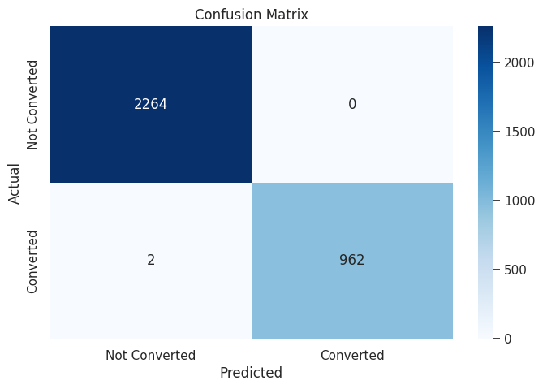

```python
# Checking performance on the training data
y_pred_train1 = d_tree.predict(X_train)
metrics_score(y_train, y_pred_train1)
```

Observations:

Precision, Recall, F1-score: All values are essentially 1.00 for both classes

Accuracy: 1.00

Confusion Matrix:

Predicted every single "Not Converted" and "Converted" case correctly, except for 2 false negatives.

Only 2 "Converted" leads were misclassified as "Not Converted"; 0 false positives.

Analysis:

Possible case of overfitting - will need to asess by test data performance.

```
               precision    recall  f1-score   support

Not Converted       0.86      0.87      0.86       971
    Converted       0.68      0.66      0.67       413

     accuracy                           0.81      1384
    macro avg       0.77      0.76      0.77      1384
 weighted avg       0.80      0.81      0.81      1384
```

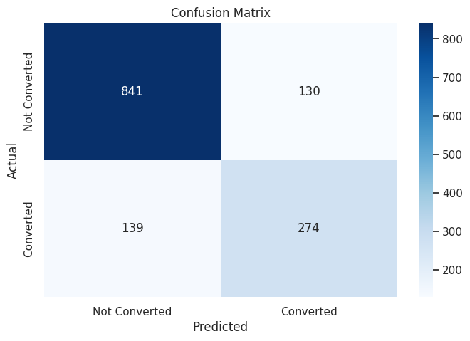

```python
# Checking performance on the testing data
y_pred_test1 = d_tree.predict(X_test)
metrics_score(y_test, y_pred_test1)
```

Observations:

Accuracy: 0.81 (81%) — much lower than on the training set.

Precision (Converted): 0.68

Recall (Converted): 0.66

F1-score (Converted): 0.67

Class Balance: 971 "Not Converted" 413 "Converted"

Analysis:

The model is much less accurate on test data than on training data- reinfornce abouve analysis of overfitting.

Recall and precision for "Converted" leads are moderate: The model is missing about one-third of actual conversions and, when it predicts "Converted," it's correct 68% of the time.

Higher accuracy for "Not Converted" class: The model predicts the majority class (Not Converted) better than the minority (Converted).

Generalization gap: The significant drop in performance compared to training suggests your model does not generalize as well to new, unseen data.

## Do we need to prune the tree?

```python
#Tune Hyperparameters
params = {
    'max_depth': [3, 4, 5, 6, None],
    'min_samples_leaf': [5, 10, 20, 50]
}
grid = GridSearchCV(DecisionTreeClassifier(random_state=1), params, cv=5)
grid.fit(X_train, y_train)

print("Best parameters:", grid.best_params_)
```

```
Best parameters: {'max_depth': 5, 'min_samples_leaf': 20}
```

```python
# Limit the tree depth & samples per leaf
d_tree_pruned = DecisionTreeClassifier(max_depth=5, min_samples_leaf=20, random_state=1)
d_tree_pruned.fit(X_train, y_train)
```

```
DecisionTreeClassifier(max_depth=5, min_samples_leaf=20, random_state=1)
```

```
               precision    recall  f1-score   support

Not Converted       0.89      0.90      0.90       971
    Converted       0.76      0.74      0.75       413

     accuracy                           0.85      1384
    macro avg       0.82      0.82      0.82      1384
 weighted avg       0.85      0.85      0.85      1384
```

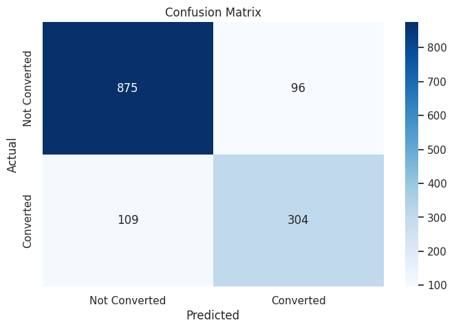

```python
# Test pruned tree
y_pred_pruned = d_tree_pruned.predict(X_test)
metrics_score(y_test, y_pred_pruned)
```

Observations:

The pruned tree achieves a 5% higher accuracy and better precision/recall balance than the original, which had lower recall/precision for the "Converted" class.

The model now correctly identifies 304 out of 413 converted leads.

Analysis:

After pruning, the Decision Tree model is less overfit and generalizes better. Accuracy and F1-score are both higher, especially for the Converted class, compared to the unpruned tree. This pruned model is more reliable for predicting lead conversions in unseen data.

## Building a Random Forest model

```python
#Additional Import
from sklearn.model_selection import GridSearchCV
```

```python
# Random Forest
rf = RandomForestClassifier(random_state=1)

# GridSearch
grid_search = GridSearchCV(estimator=rf, param_grid=param_grid,
                           cv=5, scoring='f1', n_jobs=-1, verbose=2)
grid_search.fit(X_train, y_train)

# Best estimator
best_rf = grid_search.best_estimator_
print("Best parameters:", grid_search.best_params_)
```

```
Fitting 5 folds for each of 72 candidates, totalling 360 fits
Best parameters: {'max_depth': None, 'min_samples_leaf': 4, 'min_samples_split': 10, 'n_estimators': 200}
```

```
Random Forest - Training Set Performance
               precision    recall  f1-score   support

Not Converted       0.92      0.95      0.94      2264
    Converted       0.89      0.81      0.85       964

     accuracy                           0.91      3228
    macro avg       0.90      0.88      0.89      3228
 weighted avg       0.91      0.91      0.91      3228
```

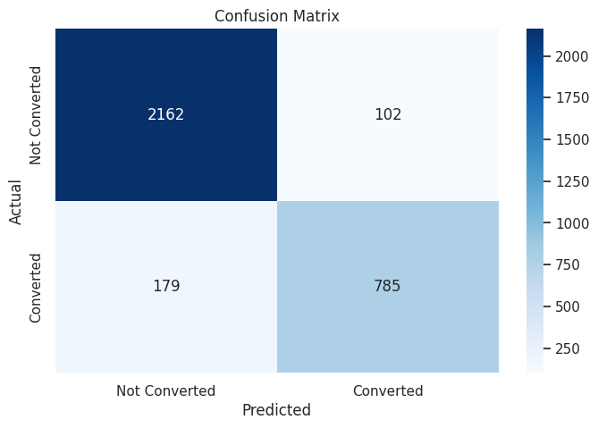

```
Random Forest - Testing Set Performance
               precision    recall  f1-score   support

Not Converted       0.89      0.92      0.91       971
    Converted       0.80      0.74      0.77       413

     accuracy                           0.87      1384
    macro avg       0.85      0.83      0.84      1384
 weighted avg       0.86      0.87      0.87      1384
```

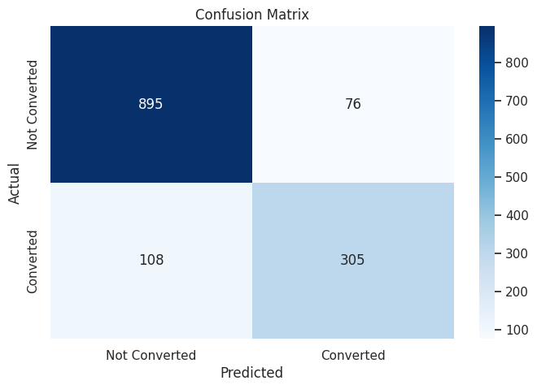

```python
# Evaluate on train and test sets
print("\nRandom Forest - Training Set Performance")
metrics_score(y_train, best_rf.predict(X_train))

print("\nRandom Forest - Testing Set Performance")
metrics_score(y_test, best_rf.predict(X_test))
```

Training Set Observations:

Accuracy: 91%

Precision/Recall/F1-score Not Converted: 0.92 / 0.95 / 0.94

Precision/Recall/F1-score Converted: 0.89 / 0.81 / 0.85

Confusion Matrix:

Not Converted: 2162 correctly, 102 misclassified as Converted

Converted: 785 correctly, 179 misclassified as Not Converted

The model performs very well on the training data, with high accuracy and balanced precision/recall for both classes. Unlike decision tree it is not overfitting to the point of perfect scores.

Test Set Observations:

Accuracy: 87%

Precision/Recall/F1-score Not Converted: 0.89 / 0.92 / 0.91

Precision/Recall/F1-score Converted: 0.80 / 0.74 / 0.77

Confusion Matrix:

Not Converted: 895 correctly, 76 misclassified as Converted

Converted: 305 correctly, 108 misclassified as Not Converted

High generalization: The test set scores are close to training scores—indicating good generalization.

Converted class: The model finds about 3 out of 4 actual conversionsand is right 80% of the time when it predicts a conversion.

Not Converted class: Strong performance.

No major overfitting: The drop from training to testing is modest and expected, given a more complex model.

## Do we need to prune the tree?

# Model is not overfitting and preforms well- no additional pruning required.

Balanced Model: Both classes are predicted with high accuracy, but the "Not Converted" class is slightly easier to predict

```python
#No pruning needed
```

## Actionable Insights and Recommendations

Insights:

Referrals have the highest conversion rates—leads referred by others are much more likely to become paid customers.

Professionals and unemployed adults convert at higher rates than students.

Students are less likely to convert—tailor messaging/offers accordingly.

Leads with high website engagement and high profile completion should be prioritized by the sales team.